# **Predictive Modeling of Visa Application Outcomes**

#### Observations

- The Island and Midwest regions exhibit the highest median offered wages. Specifically, Island region demonstrates a median wage of USD 90,678, closely followed by the Midwest region with USD 89,153.91.
- Northeast, which is the region with the highest frequency of foreign worker demand, offers comparatively lower wages with a median wafe of USD 63,276.51.
- In the Island region, 75% of workers earn an annual wage of USD 123,159.
- Contrary to initial expectation, the highest individual wage is not observed in the Island region. In fact, the Island region presents the minimum of the maximum wage values, at USD 289,878.68 . So, it has the highest median wage, but higher wages can be found in other regions. While the Island region demonstrates the highest median wage, higher wages are found in other regions, potentially attributable to a more equitable wage distribution among workers.
- The highest wage is found in the Midwest region, at USD 319,210.27.

Note: minimum wage values may be interpreted as outliers. These outliers could be attributed to the absence of a standardized unit of measurement (i.e., annually, hourly, weekly and monthly units).

#### The US government has established a prevailing wage to protect local talent and foreign workers. Let's analyze the data and see if the visa status changes with the prevailing wage

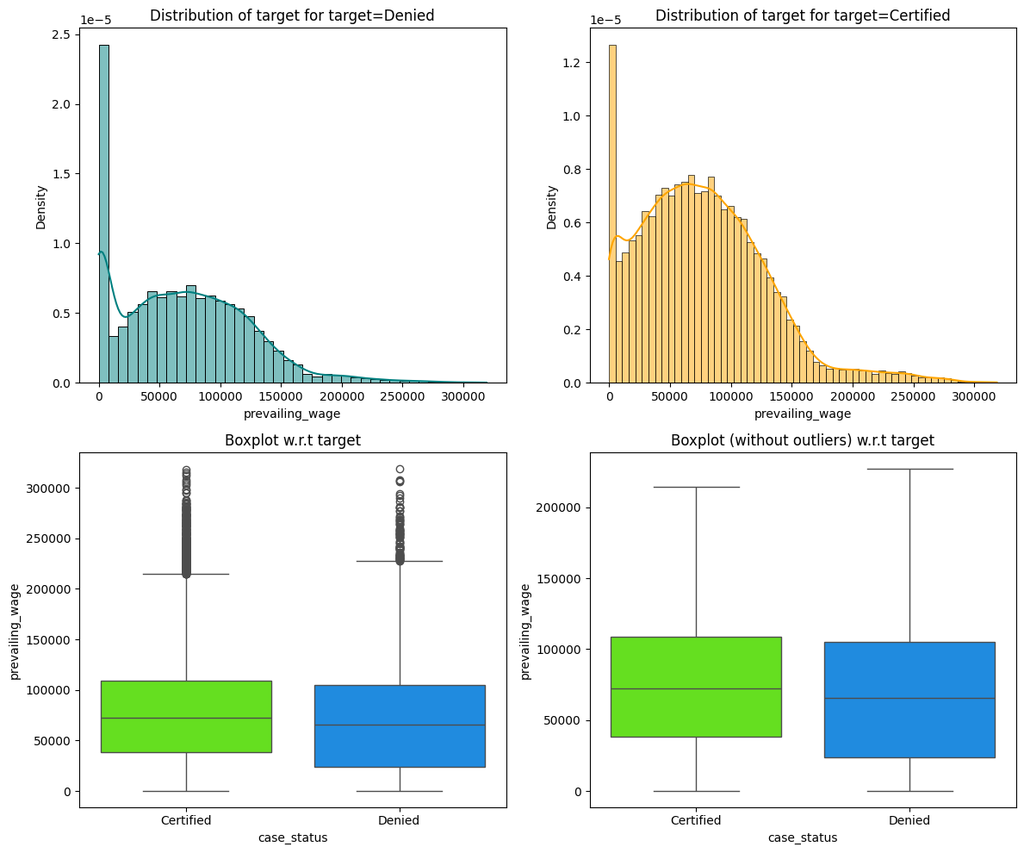

```python
distribution_plot_wrt_target(_data_copy, 'prevailing_wage', 'case_status')
```

```python
summary_stats = _data_copy.groupby('case_status')['prevailing_wage'].agg(
    mean='mean',
    Q1=lambda x: x.quantile(0.25),
    median='median',
    Q3=lambda x: x.quantile(0.75),
    min='min',
    max='max'
).reset_index()

print(summary_stats)
```

```
  case_status          mean         Q1    median           Q3     min  \
0   Certified  77293.619243  38375.330  72486.27  108879.1075  2.1367
1      Denied  68748.681580  23497.295  65431.46  105097.6400  2.9561

         max
0  318446.05
1  319210.27
```

#### Observations

Note: a significant number of wage values are potentially attributable to outliers. These outliers may, again, be a consequence of the lack of a standardized unit of measurement (e.g., annual, hourly, weekly, and monthly units)."